# STAT5003 Computational Statistical Methods

# Group Project Overview

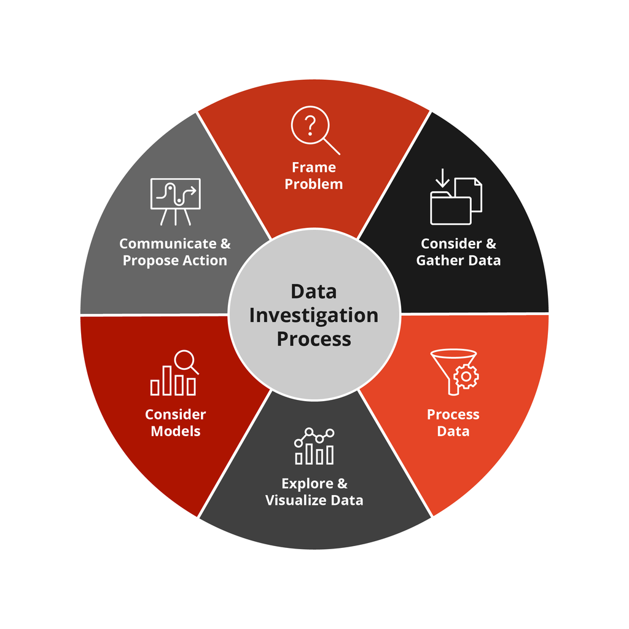

In this group project, you will apply the Data Investigation Process (DIP) to carry out a real-world **classification** task. You have the autonomy—within set guidelines—to source your own dataset and define a meaningful research problem to explore.

You are responsible for sourcing a **real dataset** appropriate to your problem.

**Conditions:**

- **Kaggle is allowed** but with restrictions:
- **Disallowed datasets** (do *not* use):
- Credit cards
- Wine quality
- Airline satisfaction
- Rainfalls
- Hospital admissions
- Traffice accidents
- Used cars
- Synthetic or simulated data
- Built-in R datasets or those used in lectures and workshops are **disallowed.**

If you use a Kaggle dataset, **verify and state the original source** (e.g., a published journal article or organisation). This is because Kaggle usually hosts copies of datasets, rather than being the primary source.

**Conditions:**

- Your dataset should meet at least 3 of these:
- Large Size: >10,000 observations
- Messy: Missing values
- Complex: >100 features, mix of continuous and categorical variables
- Integration: Combined different data sources
- Multi-class classification problem

**Innovation marks** will be awarded to:

- Datasets reflecting **local (Sydney or Australian) issues**
- Recent journal publications

## Project Timeline

### Week 1 - Week 4: Form a Group

- Create a group size of 5 with peers from your REGISTERED workshop.
- In cases where class size cannot be nicely divided by 5, a group of 4 may be permitted. Please consult with your tutors before signing up on Canvas.
- Group formation on Canvas:

Group IDs are made up of two parts:

- W01-W15: your workshop number
- G01-G12: your group number

### Week 1 - Week 7: Kick Start the Collaborative Work

### Week 7 : Project Plan and EDA

**Note**

Objective: Build understanding before modeling.

#### What to Include in Your Group Report

#### 1. Define the Problem

- What is the research question your group wants to investigate?
- Describe how this is a classification problem
- Why does it matter, and how does it connect to Sydney/Australia (applicable if you solve a local problem)?

#### 2. Describe the Data

- List the data sources used. *Simply list Kaggle as the data source will result in marks deduction* (Kaggle is a data hosting platform)
- Describe the data (how many samples and variables (numeric or categorical) are there)
- Identify the outcome variable.
- What challenges do you envision for your dataset (lots of missing values, high-dimension data, etc)

#### 3. Clean and Prepare the Data

- Perform appropriate data wrangling to make the dataset usable and interpretable for exploration (formatting, fixing errors, removing duplicates, flagging missingness/outliers etc)

#### 4. Explore and Visualize

- Use visualization to show some properties of the data.

Things you may want to explore:

- Are there outliers?
- What percentage of values are missing?
- For high dimensional data, can you plot the data in a lower dimension for visualization purpose (e.g., PCA plots)
- Do histograms/density estimations show anything interesting?

#### 5. Modelling Plan

- Outline five models (priority is given to the models taught in this unit) you plan to use.
- Describe how you plan to evaluate your classification model.

#### Submission Requirements

- Use R Markdown to write your report
- Submit as a 6-page HTML document
- Use code folding so markers can view code if needed. *Submissions without any code will result in marks deduction*
- May include up to 2 pages of appendix for:
  - References
  - Data dictionary
  - Extra tables or plots
  - The appendix will not be marked. Your 6-page report should be self-contained and include all key results.

### Week 12 : Presentation

Presentations will be held during the lecture and the workshop time. You are expected to attend the full session. Each group will have 7 minutes to present, followed by 3 minutes of Q&A.

**Note**

Objective: Communicate your work clearly and concisely.

#### What to Present

Think of your presentation as telling a data story to friends and family. Your goal is to explain your project clearly and simply to a non-technical audience.

Slides should cover:

1. Project Topic
2. Research Question & Why it matters?
3. How you process the data?
4. What Does Your Data Look Like?
5. What model(s) are you using? Why?
6. Key Results and Visuals
7. Final Insighs: What have you learned & link back to the research problem

#### Presentation Tips

- Use R Markdown to build your slides and upload by 11:59 pm on Monday of Week 12.
- Keep slides clean and simple — don’t overload with text.
- Use graphs and tables that are:
  - Easy to read
  - Clearly labelled
  - Directly support your story

> Focus on clarity, not technical detail. The audience should walk away understanding your project and why it matters.

### Week 12 : Peer Review

**Note**

Objective: Develop your critical thinking by evaluating other groups’ work.

- This is an individual task.
- Provide constructive feedback during class using a rubric.

Reflect on:

- What makes a presentation effective
- How well the problem was framed
- Whether the models and visuals were well explained

### Week 12 : Final Report

**Note**

Objective: Document your complete analysis and results as a reproducible report.

Your report should guide the reader through your data investigation process.

Include:

1. Problem Overview
2. Dataset Description
3. Exploratory Data Analysis
4. Feature Engineering
5. Classification Models Used
6. Performance Evaluation
7. Conclusion

### Week 13: Member Contribution Review

**Note**

Objective: Ensure fairness and accountability in a collaborative group project.

- Each member will complete a member review form rating teammates’ contributions.
- This task is not graded.

Be honest and respectful. All members will receive the same mark for the group components (the plan and EDA, the presentation, and the final report). However, the results of the member contribution review may lead to adjustments.

It is good to proactively ensure groups are well-functioning and to resolve any issues through active communication and negotiation, as this mirrors the future workplace. If there appear to be major group conflicts, please reach out to the teaching team by contacting your tutor or the unit coordinator early.